# Nivel Obesidad Final

## Proyecto 3 – Agrupación de datos sobre obesidad

```
                            VALERIE FAJARDO VFAJARD45354 HECTOR BELLO HBELLOS52070 HAROLD MENDOZA HMENDOZ25900
                                                             MACHINE LEARNING I
```

### Fuentes de referencia

- Zainea Maya, C. I. (2022). Seminario-de-programación (Version 1.0.0) [Computer software]. [Link](https://bit.ly/3BjfLLN)
- Bagnato, J. (2017). Aprende Machine Learning en Español Teoría + Práctica. [Link](https://leanpub.com/aprendeml)

pip install ucimlrepo

```python
from ucimlrepo import fetch_ucirepo
import requests
from bs4 import BeautifulSoup
import pandas as pd
import numpy as np
import matplotlib.pyplot as plt
import matplotlib as mpl
import seaborn as sns
from sklearn.preprocessing import OrdinalEncoder
from sklearn.preprocessing import LabelEncoder
import copy
from sklearn.cluster import KMeans
from sklearn.preprocessing import StandardScaler
from sklearn.decomposition import PCA
from sklearn.metrics import silhouette_score
%matplotlib inline
```

# 1. Reconocimiento de las variables

```python
# fetch dataset
estimation_of_obesity_levels_based_on_eating_habits_and_physical_condition = fetch_ucirepo(id=544)

# data (as pandas dataframes)
X = estimation_of_obesity_levels_based_on_eating_habits_and_physical_condition.data.features
y = estimation_of_obesity_levels_based_on_eating_habits_and_physical_condition.data.targets

# metadata
print(estimation_of_obesity_levels_based_on_eating_habits_and_physical_condition.metadata)
```

```
{'uci_id': 544, 'name': 'Estimation of Obesity Levels Based On Eating Habits and Physical Condition ', 'repository_url': 'https://archive.ics.uci.edu/dataset/544/estimation+of+obesity+levels+based+on+eating+habits+and+physical+condition', 'data_url': 'https://archive.ics.uci.edu/static/public/544/da…
```

```python
X.head()
```

|  | Gender | Age | Height | Weight | family_history_with_overweight | FAVC | FCVC | NCP | CAEC | SMOKE | CH2O | SCC | FAF | TUE | CALC | MTRANS |
| --- | --- | --- | --- | --- | --- | --- | --- | --- | --- | --- | --- | --- | --- | --- | --- | --- |
| 0 | Female | 21.0 | 1.62 | 64.0 | yes | no | 2.0 | 3.0 | Sometimes | no | 2.0 | no | 0.0 | 1.0 | no | Public_Transportation |
| 1 | Female | 21.0 | 1.52 | 56.0 | yes | no | 3.0 | 3.0 | Sometimes | yes | 3.0 | yes | 3.0 | 0.0 | Sometimes | Public_Transportation |
| 2 | Male | 23.0 | 1.80 | 77.0 | yes | no | 2.0 | 3.0 | Sometimes | no | 2.0 | no | 2.0 | 1.0 | Frequently | Public_Transportation |
| 3 | Male | 27.0 | 1.80 | 87.0 | no | no | 3.0 | 3.0 | Sometimes | no | 2.0 | no | 2.0 | 0.0 | Frequently | Walking |
| 4 | Male | 22.0 | 1.78 | 89.8 | no | no | 2.0 | 1.0 | Sometimes | no | 2.0 | no | 0.0 | 0.0 | Sometimes | Public_Transportation |

# Analisis detallado de las variables

```python
reg =[]
for col in X:
    if X[col].dtype == float:
        registro = f'Numerico Min: {X[col].min()} y Max: {X[col].max()}'
    else:
        registro = ", ".join(X[col].unique())
    reg.append(registro)

reg.append(", ".join(y['NObeyesdad'].unique()))
#registro = pd.DataFrame({'Nombre_Variables': X.columns, 'Registros_Unicos': reg})
registros = estimation_of_obesity_levels_based_on_eating_habits_and_physical_condition.variables
registros['Registros_Unicos'] = reg
registros
```

|  | name | role | type | demographic | description | units | missing_values | Registros_Unicos |
| --- | --- | --- | --- | --- | --- | --- | --- | --- |
| 0 | Gender | Feature | Categorical | Gender | None | None | no | Female, Male |
| 1 | Age | Feature | Continuous | Age | None | None | no | Numerico Min: 14.0 y Max: 61.0 |
| 2 | Height | Feature | Continuous | None | None | None | no | Numerico Min: 1.45 y Max: 1.98 |
| 3 | Weight | Feature | Continuous | None | None | None | no | Numerico Min: 39.0 y Max: 173.0 |
| 4 | family_history_with_overweight | Feature | Binary | None | Has a family member suffered or suffers from o... | None | no | yes, no |
| 5 | FAVC | Feature | Binary | None | Do you eat high caloric food frequently? | None | no | no, yes |
| 6 | FCVC | Feature | Integer | None | Do you usually eat vegetables in your meals? | None | no | Numerico Min: 1.0 y Max: 3.0 |
| 7 | NCP | Feature | Continuous | None | How many main meals do you have daily? | None | no | Numerico Min: 1.0 y Max: 4.0 |
| 8 | CAEC | Feature | Categorical | None | Do you eat any food between meals? | None | no | Sometimes, Frequently, Always, no |
| 9 | SMOKE | Feature | Binary | None | Do you smoke? | None | no | no, yes |
| 10 | CH2O | Feature | Continuous | None | How much water do you drink daily? | None | no | Numerico Min: 1.0 y Max: 3.0 |
| 11 | SCC | Feature | Binary | None | Do you monitor the calories you eat daily? | None | no | no, yes |
| 12 | FAF | Feature | Continuous | None | How often do you have physical activity? | None | no | Numerico Min: 0.0 y Max: 3.0 |
| 13 | TUE | Feature | Integer | None | How much time do you use technological devices... | None | no | Numerico Min: 0.0 y Max: 2.0 |
| 14 | CALC | Feature | Categorical | None | How often do you drink alcohol? | None | no | no, Sometimes, Frequently, Always |
| 15 | MTRANS | Feature | Categorical | None | Which transportation do you usually use? | None | no | Public_Transportation, Walking, Automobile, Mo... |
| 16 | NObeyesdad | Target | Categorical | None | Obesity level | None | no | Normal_Weight, Overweight_Level_I, Overweight_... |

```python
X.info()
```

```
<class 'pandas.core.frame.DataFrame'>
RangeIndex: 2111 entries, 0 to 2110
Data columns (total 16 columns):
 #   Column                          Non-Null Count  Dtype
---  ------                          --------------  -----
 0   Gender                          2111 non-null   object
 1   Age                             2111 non-null   float64
 2   Height                          2111 non-null   float64
 3   Weight                          2111 non-null   float64
 4   family_history_with_overweight  2111 non-null   object
 5   FAVC                            2111 non-null   object
 6   FCVC                            2111 non-null   float64
 7   NCP                             2111 non-null   float64
 8   CAEC                            2111 non-null   object
 9   SMOKE                           2111 non-null   object
 10  CH2O                            2111 non-null   float64
 11  SCC                             2111 non-null   object
 12  FAF                             2111 non-null   float64
 13  TUE                             2111 non-null   float64
 14  CALC                            2111 non-null   object
 15  MTRANS                          2111 non-null   object
dtypes: float64(8), object(8)
memory usage: 264.0+ KB
```

```python
# Creamos un sobre nombre a las variables
sob_nom =['Genero','Edad','Altura','Peso','Obesidad Familiar','Altas calorias',
          'Cons vegetales','Comidas Diarias','Refrigerios','Fuma','Cons Agua',
          'Mide calorias','Niv Fisico','Cons Tecnologico','Cons Alcohol','Tipo Transporte','Nivel Obesidad']
len(sob_nom)
base = X.join(y)
base.columns = sob_nom
base.head()
```

|  | Genero | Edad | Altura | Peso | Obesidad Familiar | Altas calorias | Cons vegetales | Comidas Diarias | Refrigerios | Fuma | Cons Agua | Mide calorias | Niv Fisico | Cons Tecnologico | Cons Alcohol | Tipo Transporte | Nivel Obesidad |
| --- | --- | --- | --- | --- | --- | --- | --- | --- | --- | --- | --- | --- | --- | --- | --- | --- | --- |
| 0 | Female | 21.0 | 1.62 | 64.0 | yes | no | 2.0 | 3.0 | Sometimes | no | 2.0 | no | 0.0 | 1.0 | no | Public_Transportation | Normal_Weight |
| 1 | Female | 21.0 | 1.52 | 56.0 | yes | no | 3.0 | 3.0 | Sometimes | yes | 3.0 | yes | 3.0 | 0.0 | Sometimes | Public_Transportation | Normal_Weight |
| 2 | Male | 23.0 | 1.80 | 77.0 | yes | no | 2.0 | 3.0 | Sometimes | no | 2.0 | no | 2.0 | 1.0 | Frequently | Public_Transportation | Normal_Weight |
| 3 | Male | 27.0 | 1.80 | 87.0 | no | no | 3.0 | 3.0 | Sometimes | no | 2.0 | no | 2.0 | 0.0 | Frequently | Walking | Overweight_Level_I |
| 4 | Male | 22.0 | 1.78 | 89.8 | no | no | 2.0 | 1.0 | Sometimes | no | 2.0 | no | 0.0 | 0.0 | Sometimes | Public_Transportation | Overweight_Level_II |

```python
# tipificacion de variables
tip = pd.DataFrame({'Variables': sob_nom, 'Tipo variable': registros['type']})
```

```python
def grafico_binarios(df, X, rellen):

    #f, ax = plt.subplots(figsize=(6, 4))
    #sns.despine(f)

    sns.histplot(
        df,
        x=X, hue=rellen,
        multiple="stack",
        palette="light:m_r",
        edgecolor=".3",
        linewidth=.5,
        log_scale=True,
    )
    #plt.legend(fontsize=8, ncol=1, handlelength=1.5, borderaxespad=0.5)
    plt.title(f"Tipo Obesidad segun {rellen}")
    plt.xticks(rotation=45, ha='right', fontsize=8)
```

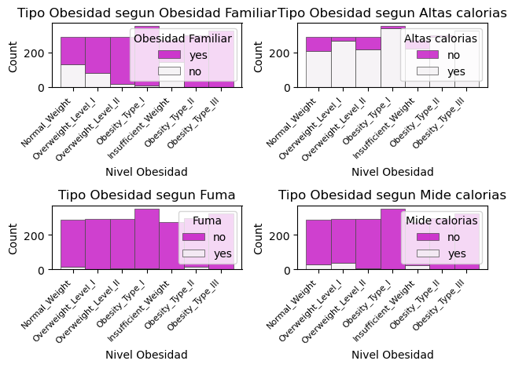

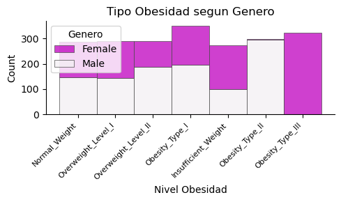

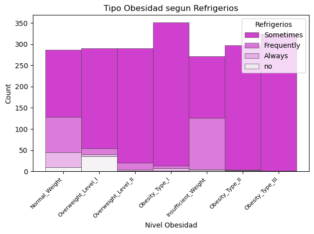

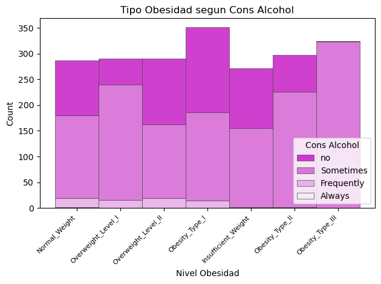

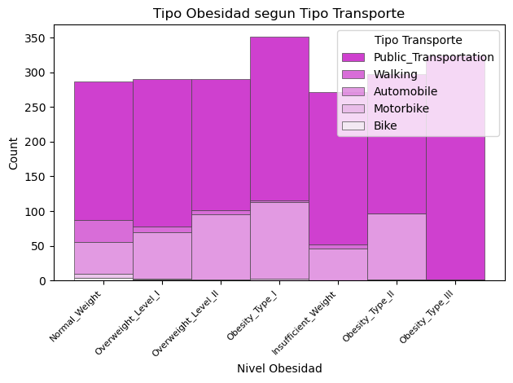

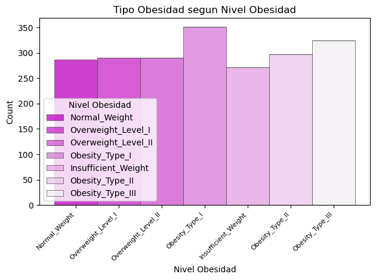

```python
var =""
i = 1
for col in base:
    var = tip[tip['Variables'].isin([col])]

    if var.iloc[0,1] == 'Binary':

        plt.subplot(2, 2, i)
        grafico_binarios(base,'Nivel Obesidad',col)
        i=i +1
#f, ax = plt.subplots(figsize=(20, 15))
#sns.despine(f)
#plt.figure(figsize=(45, 25))
#plt.subplots_adjust(left=0.1, right=0.9, bottom=0.1, top=1.9, wspace=1.4, hspace=1.4)
plt.tight_layout()
plt.show()

var =""
i = 1
f, ax = plt.subplots(figsize=(5, 3))
sns.despine(f)
for col in base:
    var = tip[tip['Variables'].isin([col])]

    if var.iloc[0,1] == 'Categorical':

        #plt.subplot(2, 3, i)
        grafico_binarios(base,'Nivel Obesidad',col)
        i=i +1
        #plt.legend(loc = 'lower right')

        #plt.figure(figsize=(5, 3))
        plt.tight_layout()
        plt.show()
```

# Transformacion de variables

```python
base
df_bs = copy.deepcopy(base)
```

## Modelo # 1: Analisis de cluster

```python
variables_numericas = base.select_dtypes(include=['int64', 'float64']).columns.tolist()
variables_cualitativas = base.select_dtypes(include=['object']).columns.tolist()

print("Variables Numéricas:", variables_numericas)
print("Variables Cualitativas:", variables_cualitativas)
```

```
Variables Numéricas: ['Edad', 'Altura', 'Peso', 'Cons vegetales', 'Comidas Diarias', 'Cons Agua', 'Niv Fisico', 'Cons Tecnologico']
Variables Cualitativas: ['Genero', 'Obesidad Familiar', 'Altas calorias', 'Refrigerios', 'Fuma', 'Mide calorias', 'Cons Alcohol', 'Tipo Transporte', 'Nivel Obesidad']
```

```python
scaler = StandardScaler()
data_scaled = scaler.fit_transform(base[variables_numericas])
```

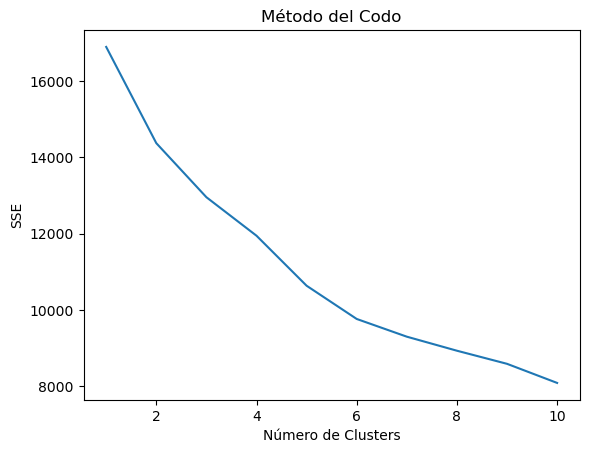

```python
sse = []
for k in range(1, 11):
    kmeans = KMeans(n_clusters=k, random_state=0)
    kmeans.fit(data_scaled)
    sse.append(kmeans.inertia_)

plt.plot(range(1, 11), sse)
plt.xlabel('Número de Clusters')
plt.ylabel('SSE')
plt.title('Método del Codo')
plt.show()
```

La gráfica del método del codo sugiere que el punto de inflexión podría estar en 3 o 4 clusters. Para elegir el número de clusters óptimo, se hace un análisis adicional con el método de coeficiente de silueta, que evalúa la calidad de los clusters.

```python
num_clusters = [3, 4]
for n_clusters in num_clusters:
    kmeans = KMeans(n_clusters=n_clusters, random_state=0)
    cluster_labels = kmeans.fit_predict(data_scaled)
    silhouette_avg = silhouette_score(data_scaled, cluster_labels)
    print(f"Para n_clusters = {n_clusters}, el coeficiente de silueta es: {silhouette_avg:.4f}")
optimal_clusters = 3  # Puedes ajustar esto según los resultados anteriores
kmeans = KMeans(n_clusters=optimal_clusters, random_state=0)
base['Cluster'] = kmeans.fit_predict(data_scaled)
```

```
Para n_clusters = 3, el coeficiente de silueta es: 0.1499
Para n_clusters = 4, el coeficiente de silueta es: 0.1195
```

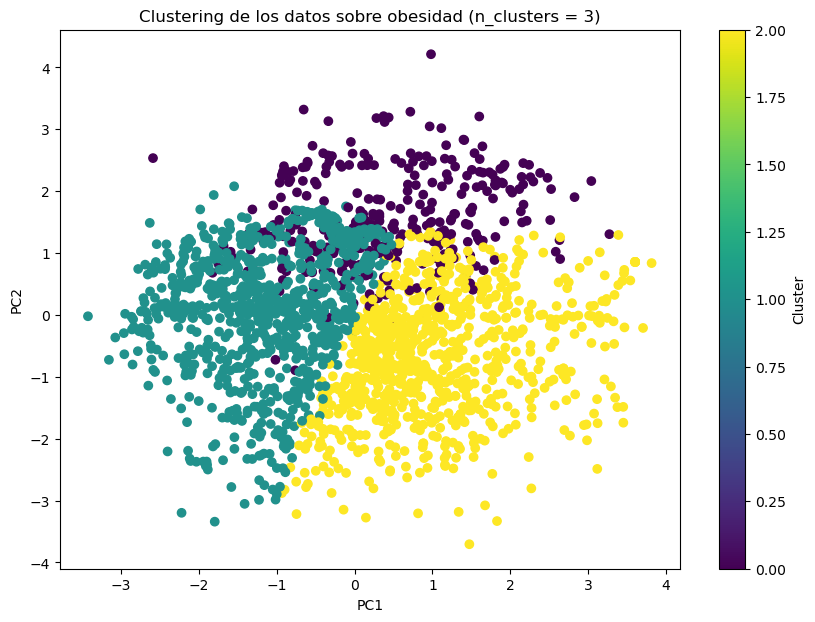

```python
optimal_clusters = 3
kmeans = KMeans(n_clusters=optimal_clusters, random_state=0)
base['Cluster'] = kmeans.fit_predict(data_scaled)

pca = PCA(n_components=2)
data_pca = pca.fit_transform(data_scaled)

plt.figure(figsize=(10, 7))
plt.scatter(data_pca[:, 0], data_pca[:, 1], c=base['Cluster'], cmap='viridis')
plt.xlabel('PC1')
plt.ylabel('PC2')
plt.title(f'Clustering de los datos sobre obesidad (n_clusters = {optimal_clusters})')
plt.colorbar(label='Cluster')
plt.show()
```

1. Hipótesis: Las personas que realizan actividad física con mayor frecuencia tienen niveles más bajos de obesidad.

```python
base['Obesidad Familiar'] = base['Obesidad Familiar'].map({'yes': 1, 'no': 0})
base['Altas calorias'] = base['Altas calorias'].map({'yes': 1, 'no': 0})

print("Valores únicos en 'Obesidad Familiar':", base['Obesidad Familiar'].unique())
print("Valores únicos en 'Altas calorias':", base['Altas calorias'].unique())
```

```
Valores únicos en 'Obesidad Familiar': [1 0]
Valores únicos en 'Altas calorias': [0 1]
```

```python
for cluster in base['Cluster'].unique():
    cluster_data = base[base['Cluster'] == cluster]
    family_history_percent = cluster_data['Obesidad Familiar'].mean() * 100
    high_caloric_food_percent = cluster_data['Altas calorias'].mean() * 100
    print(f"Cluster {cluster}:")
    print(f"  % con historial familiar de sobrepeso: {family_history_percent:.2f}%")
    print(f"  % que consume alimentos calóricos frecuentemente: {high_caloric_food_percent:.2f}%\n")
```

```
Cluster 2:
  % con historial familiar de sobrepeso: 64.45%
  % que consume alimentos calóricos frecuentemente: 81.08%

Cluster 1:
  % con historial familiar de sobrepeso: 94.52%
  % que consume alimentos calóricos frecuentemente: 94.63%

Cluster 0:
  % con historial familiar de sobrepeso: 92.33%
  % que consume alimentos calóricos frecuentemente: 90.49%
```

El Cluster 2, parece tener una menor tendencia a la obesidad, presenta un porcentaje menor de historial familiar de sobrepeso (64.45%) y un menor consumo de alimentos calóricos frecuentemente (81.08%) en comparación con los clusters 1 y 0.

Clusters 1 y 0 tienen porcentajes más altos de historial familiar de sobrepeso (94.52% y 92.33%, respectivamente) y un consumo más alto de alimentos calóricos (94.63% y 90.49%, respectivamente).

2. Hipótesis: Las personas que tienen un consumo de agua adecuado y practican actividad física regularmente tienen una menor tendencia a obesidad alta.

```python
base['Cons Agua'] = base['Cons Agua'].astype(int)
base['Niv Fisico'] = base['Niv Fisico'].astype(int)

for cluster in base['Cluster'].unique():
    cluster_data = base[base['Cluster'] == cluster]

    ch2o_counts = cluster_data['Cons Agua'].value_counts(normalize=True) * 100
    faf_counts = cluster_data['Niv Fisico'].value_counts(normalize=True) * 100

    print(f"Cluster {cluster}:")
    print("  Consumo de agua (porcentaje):")

    for level, percent in ch2o_counts.sort_index().items():
        if level == 1:
            label = "Menos de un litro"
        elif level == 2:
            label = "Entre 1 y 2 litros"
        elif level == 3:
            label = "Más de 2 litros"
        print(f"    {label}: {percent:.2f}%")

    print("  Actividad física (porcentaje):")

    for level, percent in faf_counts.sort_index().items():
        if level == 0:
            label = "No tengo actividad física"
        elif level == 1:
            label = "1 o 2 días"
        elif level == 2:
            label = "2 o 4 días"
        elif level == 3:
            label = "4 o 5 días"
        print(f"    {label}: {percent:.2f}%")
```

```
Cluster 2:
  Consumo de agua (porcentaje):
    Menos de un litro: 45.99%
    Entre 1 y 2 litros: 47.36%
    Más de 2 litros: 6.65%
  Actividad física (porcentaje):
    No tengo actividad física: 53.10%
    1 o 2 días: 29.70%
    2 o 4 días: 13.88%
    4 o 5 días: 3.33%
Cluster 1:
  Consumo de agua (porcentaje):
    Menos de un litro: 19.93%
    Entre 1 y 2 litros: 69.99%
    Más de 2 litros: 10.08%
  Actividad física (porcentaje):
    No tengo actividad física: 39.54%
    1 o 2 días: 39.87%
    2 o 4 días: 16.32%
    4 o 5 días: 4.27%
Cluster 0:
  Consumo de agua (porcentaje):
    Menos de un litro: 57.06%
    Entre 1 y 2 litros: 39.26%
    Más de 2 litros: 3.68%
  Actividad física (porcentaje):
    No tengo actividad física: 57.36%
    1 o 2 días: 30.98%
    2 o 4 días: 9.51%
    4 o 5 días: 2.15%
```

El Cluster 1 destaca por un mayor consumo de agua (69.99% entre 1 y 2 litros) y una buena participación de actividad física (39.87% realiza ejercicio entre 1 y 2 días a la semana). Sin embargo, aun un 39.54% de los individuos no realiza ninguna actividad física. El Cluster 2 tiene un consumo de agua equilibrado, con un 47.36% que consume entre 1 y 2 litros, pero más de la mitad (53.10%) no realiza actividad física. En el Cluster 0, la mayoría consume menos de un litro de agua (57.06%) y presenta el mayor porcentaje de inactividad física (57.36%).

En general, el Cluster 1 es el más saludable en términos de consumo de agua y actividad física, mientras que los Clusters 0 y 2 muestran mayores niveles de sedentarismo y menor consumo de agua.

3. Hipótesis: Aquellas personas que fuman o tienen bajos niveles de consumo de vegetales tienen más probabilidad de estar en niveles altos de obesidad.

```python
base['Fuma'] = base['Fuma'].map({'yes': 1, 'no': 0})

print("Valores únicos en 'Fuma':", base['Fuma'].unique())
```

```
Valores únicos en 'Fuma': [0 1]
```

```python
base['Cons vegetales'] = base['Cons vegetales'].astype(int)

for cluster in base['Cluster'].unique():
    cluster_data = base[base['Cluster'] == cluster]
    smoker_percent = cluster_data['Fuma'].mean() * 100


    fcvc_counts = cluster_data['Cons vegetales'].value_counts().sort_index()
    fcvc_counts = fcvc_counts.rename(index={1: 'Nunca', 2: 'A veces', 3: 'Siempre'})

    print(f"Cluster {cluster}:")
    print(f"  % de fumadores: {smoker_percent:.2f}%")
    print(f"  Frecuencia de consumo de vegetales:")

    for category, count in fcvc_counts.items():
        print(f"    {category}: {count} personas ({(count / len(cluster_data)) * 100:.2f}%)")

    print()
```

```
Cluster 2:
  % de fumadores: 1.72%
  Frecuencia de consumo de vegetales:
    Nunca: 127 personas (14.56%)
    A veces: 555 personas (63.65%)
    Siempre: 190 personas (21.79%)

Cluster 1:
  % de fumadores: 2.30%
  Frecuencia de consumo de vegetales:
    Nunca: 63 personas (6.90%)
    A veces: 432 personas (47.32%)
    Siempre: 418 personas (45.78%)

Cluster 0:
  % de fumadores: 2.45%
  Frecuencia de consumo de vegetales:
    Nunca: 12 personas (3.68%)
    A veces: 270 personas (82.82%)
    Siempre: 44 personas (13.50%)
```

El Cluster 1 tiene la mayor proporción de personas que consumen vegetales “siempre” (45.78%), seguido del Cluster 2, donde el 63.65% consume vegetales “a veces”. El Cluster 0 tiene el mayor porcentaje de personas que consumen vegetales “a veces” (82.82%), aunque con una menor proporción que el Cluster 1 que consume “siempre”.

En resumen, el Cluster 1 tiene la mayor proporción de personas que consumen vegetales regularmente, mientras que el Cluster 0 es el que tiene más personas que solo consumen vegetales ocasionalmente. El Cluster 2 se encuentra en un punto intermedio, con un bajo porcentaje de fumadores y un consumo moderado de vegetales.

4. Hipótesis: Las personas que utilizan medios de transporte activos (como caminar o usar bicicleta) tienden a agruparse en clusters de obesidad baja.

```python
active_transport_modes = ['Walking', 'Bike']

for cluster in base['Cluster'].unique():
    cluster_data = base[base['Cluster'] == cluster]
    active_transport_percent = cluster_data['Tipo Transporte'].apply(lambda x: x in active_transport_modes).mean() * 100
    print(f"Cluster {cluster}:")
    print(f"  % que usa transporte activo (caminar o bicicleta): {active_transport_percent:.2f}%\n")
```

```
Cluster 2:
  % que usa transporte activo (caminar o bicicleta): 3.90%

Cluster 1:
  % que usa transporte activo (caminar o bicicleta): 2.41%

Cluster 0:
  % que usa transporte activo (caminar o bicicleta): 2.15%
```

El Cluster 2 presenta el porcentaje más alto de uso de transporte activo (3.90%), mientras que los clusters 1 y 0 tienen porcentajes menores (2.41% y 2.15%, respectivamente).

Aunque el porcentaje de uso de transporte activo es bajo en todos los clusters, el Cluster 2, que parece tener menores niveles de obesidad, tiene el porcentaje más alto de uso de transporte activo. Esto sugiere una posible relación entre la actividad de transporte activo y una menor prevalencia de obesidad, aunque el impacto de este factor no parece ser muy significativo dado el bajo porcentaje general.

## Conclusión General

Este estudio ha aplicado técnicas de aprendizaje no supervisado para explorar los patrones subyacentes en un conjunto de datos de obesidad que abarca México, Perú y Colombia. Mediante la reducción de dimensionalidad y el clustering, se han identificado grupos distintos de individuos con características y hábitos asociados a diferentes niveles de obesidad. Los resultados obtenidos sugieren que factores como el historial familiar, la dieta, la actividad física y el estilo de vida son determinantes clave en la clasificación de los individuos dentro de estos grupos. Este análisis proporciona una base sólida para futuras investigaciones que busquen desarrollar modelos predictivos más precisos y personalizados para la obesidad en la región latinoamericana.

```python
label_encoder = LabelEncoder()
ordinal_encoder = OrdinalEncoder()
for col in df_bs:
    var = tip[tip['Variables'].isin([col])]
    if var.iloc[0,0] == 'Refrigerios' or var.iloc[0,0] =='Cons Alcohol' or var.iloc[0,0] == 'Nivel Obesidad':
        df_bs[col] = ordinal_encoder.fit_transform(df_bs[[col]])

    elif var.iloc[0,1] == 'Binary' or var.iloc[0,1] == 'Categorical':
        df_bs[col] = label_encoder.fit_transform(df_bs[col])

df_bs
```

|  | Genero | Edad | Altura | Peso | Obesidad Familiar | Altas calorias | Cons vegetales | Comidas Diarias | Refrigerios | Fuma | Cons Agua | Mide calorias | Niv Fisico | Cons Tecnologico | Cons Alcohol | Tipo Transporte | Nivel Obesidad |
| --- | --- | --- | --- | --- | --- | --- | --- | --- | --- | --- | --- | --- | --- | --- | --- | --- | --- |
| 0 | 0 | 21.000000 | 1.620000 | 64.000000 | 1 | 0 | 2.0 | 3.0 | 2.0 | 0 | 2.000000 | 0 | 0.000000 | 1.000000 | 3.0 | 3 | 1.0 |
| 1 | 0 | 21.000000 | 1.520000 | 56.000000 | 1 | 0 | 3.0 | 3.0 | 2.0 | 1 | 3.000000 | 1 | 3.000000 | 0.000000 | 2.0 | 3 | 1.0 |
| 2 | 1 | 23.000000 | 1.800000 | 77.000000 | 1 | 0 | 2.0 | 3.0 | 2.0 | 0 | 2.000000 | 0 | 2.000000 | 1.000000 | 1.0 | 3 | 1.0 |
| 3 | 1 | 27.000000 | 1.800000 | 87.000000 | 0 | 0 | 3.0 | 3.0 | 2.0 | 0 | 2.000000 | 0 | 2.000000 | 0.000000 | 1.0 | 4 | 5.0 |
| 4 | 1 | 22.000000 | 1.780000 | 89.800000 | 0 | 0 | 2.0 | 1.0 | 2.0 | 0 | 2.000000 | 0 | 0.000000 | 0.000000 | 2.0 | 3 | 6.0 |
| ... | ... | ... | ... | ... | ... | ... | ... | ... | ... | ... | ... | ... | ... | ... | ... | ... | ... |
| 2106 | 0 | 20.976842 | 1.710730 | 131.408528 | 1 | 1 | 3.0 | 3.0 | 2.0 | 0 | 1.728139 | 0 | 1.676269 | 0.906247 | 2.0 | 3 | 4.0 |
| 2107 | 0 | 21.982942 | 1.748584 | 133.742943 | 1 | 1 | 3.0 | 3.0 | 2.0 | 0 | 2.005130 | 0 | 1.341390 | 0.599270 | 2.0 | 3 | 4.0 |
| 2108 | 0 | 22.524036 | 1.752206 | 133.689352 | 1 | 1 | 3.0 | 3.0 | 2.0 | 0 | 2.054193 | 0 | 1.414209 | 0.646288 | 2.0 | 3 | 4.0 |
| 2109 | 0 | 24.361936 | 1.739450 | 133.346641 | 1 | 1 | 3.0 | 3.0 | 2.0 | 0 | 2.852339 | 0 | 1.139107 | 0.586035 | 2.0 | 3 | 4.0 |
| 2110 | 0 | 23.664709 | 1.738836 | 133.472641 | 1 | 1 | 3.0 | 3.0 | 2.0 | 0 | 2.863513 | 0 | 1.026452 | 0.714137 | 2.0 | 3 | 4.0 |

2111 rows × 17 columns

# Construccion de las Variables de los modelos

```python
X_bs = df_bs.drop('Nivel Obesidad', axis=1)
y_bs = df_bs['Nivel Obesidad']
```

```python
labels=df_bs['Nivel Obesidad'].values
labels[0:5]
```

```
array([1., 1., 1., 5., 6.])
```

```
Dimension del DF X (2111, 16)
[0.16278132 0.11654264 0.09558839 0.08480334 0.07033629 0.06665355
 0.06135247 0.05444052 0.05120547 0.04925825 0.04743343 0.04287739
 0.03756736 0.02504009 0.02051196 0.01360753]
suma: 0.8603956673193555
```

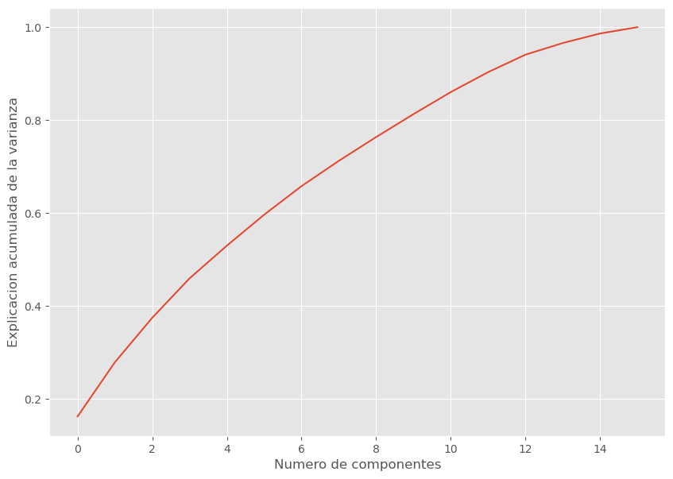

```python
plt.rcParams['figure.figsize'] = (10, 7)
plt.style.use('ggplot')

#normalizamos los datos
scaler=StandardScaler()
scaler.fit(X_bs) # calculo la media para poder hacer la transformacion
X_scaled=scaler.transform(X_bs)# Ahora si, escalo los datos y los normalizo

#Instanciamos objeto PCA y aplicamos
pca=PCA(n_components=16) # Otra opción es instanciar pca sólo con dimensiones nuevas hasta obtener un mínimo "explicado" ej.: pca=PCA(.85)
pca.fit(X_scaled) # obtener los componentes principales
X_pca=pca.transform(X_scaled) # convertimos nuestros datos con las nuevas dimensiones de PCA

print("Dimension del DF X", X_pca.shape)
expl = pca.explained_variance_ratio_
print(expl)
print('suma:',sum(expl[0:11]))

#graficamos el acumulado de varianza explicada en las nuevas dimensiones
plt.plot(np.cumsum(pca.explained_variance_ratio_))
plt.xlabel('Numero de componentes')
plt.ylabel('Explicacion acumulada de la varianza')
plt.show()
```

[figure not shown]

```python
#graficamos en 2 Dimensiones, tomando los 2 primeros componentes principales
Xax=X_pca[:,0]
Yax=X_pca[:,1]
labels=df_bs['Nivel Obesidad'].values
cdict={0:'grey', 1:'blue', 2:'green', 3:'purple',
       4:'orange',5:'yellow', 6:'red',
       }
labl={0:'Normal_Weight', 1:'Obesity_Type_I', 2:'Obesity_Type_II',
       3:'Obesity_Type_III',4:'Overweight_Level_I', 5:'Overweight_Level_II',
       6:'Insufficient_Weight'}
marker={0:'o', 1:'x', 2:'+', 3:'v', 4:'<',5:'s', 6:'*'}
alpha={0:.3,1:.3,2:.3,3:.3,4:.3,5:.3,6:.3}
fig,ax=plt.subplots(figsize=(7,5))
fig.patch.set_facecolor('white')
for l in np.unique(labels):
    ix=np.where(labels==l)
    ax.scatter(Xax[ix],Yax[ix],c=cdict[l],label=labl[l],s=40,marker=marker[l],alpha=alpha[l])

plt.xlabel("First Principal Component",fontsize=14)
plt.ylabel("Second Principal Component",fontsize=14)
plt.legend()
plt.show()
```